# CUBI advanced R bioinformatics course / 02

2020-05-22

## Creating your own gene sets

## Why use your own gene sets?

- Testing a specific hypothesis
- Your expert knowledge on the subject is better!
- Avoiding the pitfall of multiple testing

## What do we need: tmod

- A mapping between genes and gene sets

We need a **named list**. Names on that list should be identifiers of the gene sets (preferably short). The list should contain **character vectors**. The elements of these vectors should be the gene identifiers.

- A data frame describing the gene sets

`tmod` requires in addition a **data frame** which is the annotation of the gene sets. It must contain the columns `ID` and `Title`, but can also contain other columns which are then used for subsetting.

## Getting the mapping

Say, we have a couple of gene sets saved in an XLSX file, `"custom_gs.xlsx"` with multiple sheets.

[figure not shown]

## Getting the mapping

```r
library(readxl)
excel_sheets("custom_gs.xlsx")
```

```
## [1] "Jak_Stat"      "Interferon"    "MycSignalling"
```

```r
cgs <- lapply(1:3, function(i) read_xlsx("custom_gs.xlsx", sheet=i))
```

## Getting the mapping

This list contains `tibbles` (a sort of a data frame) instead of character vectors. To get what we need we need only the *first column* of each spreadsheet!

```r
cgs <- lapply(1:3,
  function(i) read_xlsx("custom_gs.xlsx", sheet=i)[[1]])
names(cgs) <- excel_sheets("custom_gs.xlsx")
```

## Creating tmod database

`tmod` uses objects which contain both the data frame and the list. `cluster profiler` simply uses the mapping (but its output is less informative).

```r
gs.df <- data.frame(ID=names(cgs),
  Title=c("JAK / STAT pathway signalling",
          "Interferon a+g signalling",
          "MYC targets"))
tcgs <- makeTmod(modules=gs.df, modules2genes=cgs)
tcgs
```

```
## An object of class "tmod"
##  3 modules, 687 genes
```

## Creating gene sets from MSigDB

How to create the `cgs`/`tcgs` from MSigDB.

```r
library(msigdbr)
h.df <- msigdbr("Homo sapiens", "H")
head(h.df)
```

```
## # A tibble: 6 x 9
##   gs_id gs_name               gs_cat gs_subcat human_gene_symbol species_name entrez_gene gene_symbol sources
##   <chr> <chr>                 <chr>  <chr>     <chr>             <chr>              <int> <chr>       <chr>
## 1 M5905 HALLMARK_ADIPOGENESIS H      ""        ABCA1             Homo sapiens          19 ABCA1       <NA>
## 2 M5905 HALLMARK_ADIPOGENESIS H      ""        ABCB8             Homo sapiens       11194 ABCB8       <NA>
## 3 M5905 HALLMARK_ADIPOGENESIS H      ""        ACAA2             Homo sapiens       10449 ACAA2       <NA>
## 4 M5905 HALLMARK_ADIPOGENESIS H      ""        ACADL             Homo sapiens          33 ACADL       <NA>
## 5 M5905 HALLMARK_ADIPOGENESIS H      ""        ACADM             Homo sapiens          34 ACADM       <NA>
## 6 M5905 HALLMARK_ADIPOGENESIS H      ""        ACADS             Homo sapiens          35 ACADS       <NA>
```

## Creating gene sets from MSigDB

How to create the `cgs`/`tcgs` from MSigDB.

```r
h.names <- unique(h.df$gs_name)
h.cgs <- lapply(h.names, function(n)
  h.df$human_gene_symbol[ h.df$gs_name == n ])
h.names <- gsub("HALLMARK_", "", h.names)
names(h.cgs) <- h.names

htmod <- makeTmod(modules=data.frame(ID=h.names, Title=h.names), modules2genes=h.cgs)
htmod
```

```
## An object of class "tmod"
##  50 modules, 4383 genes
```

## Using custom tmod modules

```r
tmodCERNOtest(res$SYMBOL[ order(res$pvalue) ], mset=tcgs)
```

```
##                          ID                         Title cerno  N1  AUC cES P.Value adj.P.Val
## Interferon       Interferon     Interferon a+g signalling  1217 220 0.77 2.8 4.0e-74   1.2e-73
## Jak_Stat           Jak_Stat JAK / STAT pathway signalling   883 265 0.66 1.7 4.1e-20   6.2e-20
## MycSignalling MycSignalling                   MYC targets   731 234 0.69 1.6 7.8e-14   7.8e-14
```

## For cluster profiler

Cluster profiler uses in its functions the option `TERM2GENE` which takes a data frame with gene set names in one column and gene ids in the other.

It is really easy to convert a gene set list to a gene set data frame.

Of course, we can use the results directly.

```r
cgs.df <- Reduce(rbind,
  lapply(names(cgs), function(n) data.frame(ID=n, GENE=cgs[[n]])))
```

## More on tmod and cluster profiler

## Get the newest tmod!

Github is a development platform, extremely convenient for tracking the versions of your project (not only for programming!).

`devtools` is a great R package for developing packages. `devtools::install_github` allows installation of R packages directly from github.

```r
install.packages("devtools")
devtools::install_github("https://github.com/january3/tmod")
```

## Important tmod functions

| category | function | description |
| --- | --- | --- |
| testing | tmodCERNOtest | enrichment test on a ranked list |
| ,, | tmodHGtest | hypergeometric test on foreground / background |
| ,, | tmodPCA | combining PCA with gene set enrichments |
| ,, | tmodUtest | enrichment test on a ranked list |
| ,, | tmodZtest | enrichment test on a ranked list |
| ,, | tmodPLAGEtest | enrichment test on an expression matrix |
| ,, | tmodDecideTests | calculate how many genes from a given gene set are up- or down-regulated |
| visualization | tmodPanelPlot | heatmap for multiple contrasts containing loads of information |
| ,, | evidencePlot | Detailed inspection of enrichment in a single gene set of a single module |
| ,, | upset | Detailed inspection of enrichment in a single gene set |
| ,, | tmodTagcloud | Create a cloud of enrichment terms |
| ,, | tmodPCA | combine PCA with gene set enrichments |
| ,, | showGene | combined beeswarm+boxplot |
| import | tmodImportMSigDB | Read the XML file from MSigDB |
| tools | getModuleMembers | return the vector with gene IDs belonging to a gene set |

## Using cluster profiler

[output not shown]

## Using cluster profiler HG

Input:

- `gene`: foreground set
- `universe`: all genes
- `TERM2GENE`: data frame mapping gene sets to genes

```r
sign  <- !is.na(res$padj) & res$padj < .01 & abs(res$log2FoldChange) > 1
fg <- res$SYMBOL[sign]
res.cphg <- enricher(fg, universe=res$SYMBOL, TERM2GENE=cgs.df)
head(res.cphg)[,1:5]
```

```
##                    ID Description GeneRatio BgRatio  pvalue
## Interferon Interferon  Interferon   134/261 220/672 3.4e-16
```

## Using cluster profiler GSEA

Input:

- decreasingly ordered numerical vector; names are the IDs of the genes
- data frame assigning gene set IDs to genes

```r
vec <- nrow(res):1
names(vec) <- res$SYMBOL[ order(res$pvalue) ]
res.cp <- GSEA(vec, TERM2GENE=cgs.df)
head(res.cp)[, 1:10]
```

```
##                          ID   Description setSize enrichmentScore NES pvalue p.adjust qvalues  rank                   leading_edge
## Interferon       Interferon    Interferon     220            0.58 2.1  0.001    0.001      NA  3515 tags=59%, list=17%, signal=50%
## Jak_Stat           Jak_Stat      Jak_Stat     265            0.37 1.4  0.001    0.001      NA  8347 tags=58%, list=39%, signal=36%
## MycSignalling MycSignalling MycSignalling     234            0.40 1.5  0.001    0.001      NA 10056 tags=77%, list=47%, signal=41%
```

## Cluster profiler GSEA vs tmodCERNOtest

We can compare the p-value obtained from GSEA with these from tmod:

```r
## get the tmod results, but do not filter by q-value
res.tmod.cerno.full <- tmodCERNOtest(res$SYMBOL[ order(res$pvalue) ],
  mset=htmod, qval=Inf, order.by="n")

## get the GSEA results, but do not filter by q-value
## also, increase the number of permutations
res.cp <- GSEA(vec, TERM2GENE=h[ , c("gs_name", "human_gene_symbol") ],
  pvalueCutoff=Inf, nPerm=1e6)
res.cp <- as.data.frame(res.cp)[ , -ncol(res.cp) ]
res.cp$ID <- gsub("HALLMARK_", "", res.cp$ID)

## order the cp results identically to tmod
res.cp <- res.cp[ match(res.tmod.cerno.full$ID, res.cp$ID), ]
```

## Cluster profiler GSEA vs tmodCERNOtest

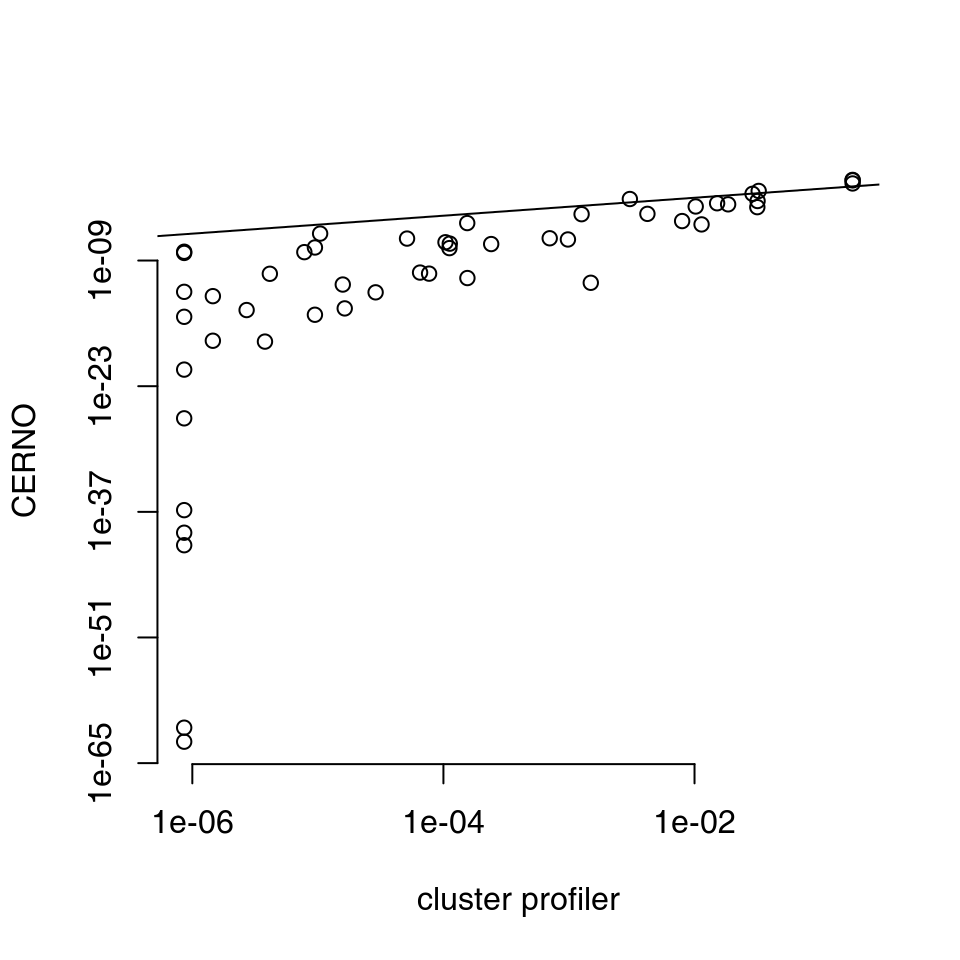

## Interpretation and visualization

## Which genes are in a gene set?

```r
## using directly our mapping list
h.cgs[["INTERFERON_GAMMA_RESPONSE"]]

## using a data frame
sel <- h.df$gs_name == "HALLMARK_INTERFERON_GAMMA_RESPONSE"
h.df$human_gene_symbol[sel]

## using tmod, directly or with a function
htmod$MODULES2GENES[["INTERFERON_GAMMA_RESPONSE"]]

getModuleMembers("INTERFERON_GAMMA_RESPONSE",
  mset=htmod)[[1]]
```

## Inspect individual genes

```r
lcounts <- assay(rlog(ds))
genes <- getModuleMembers("LI.M127")[[1]]
genes
```

```
##  [1] "TAP1"   "IFIH1"  "IRF7"   "PARP9"  "STAT1"  "PLSCR1" "IFITM1" "HERC5"  "DDX60"  "USP18"  "RSAD2"  "IFIT1"
```

```r
sel.genes <- annot$SYMBOL %in% genes
head(annot[ sel.genes, ])
```

```
##            PrimaryID         ENSEMBL SYMBOL ENTREZID       REFSEQ                                                     GENENAME
## 4227 ENSG00000115267 ENSG00000115267  IFIH1    64135    NM_022168                  interferon induced with helicase C domain 1
## 4257 ENSG00000115415 ENSG00000115415  STAT1     6772    NM_007315           signal transducer and activator of transcription 1
## 6582 ENSG00000134321 ENSG00000134321  RSAD2    91543    NM_080657            radical S-adenosyl methionine domain containing 2
## 7170 ENSG00000137628 ENSG00000137628  DDX60    55601    NM_017631                                       DExD/H-box helicase 60
## 7341 ENSG00000138496 ENSG00000138496  PARP9    83666 NM_001146102                  poly(ADP-ribose) polymerase family member 9
## 7360 ENSG00000138646 ENSG00000138646  HERC5    51191    NM_016323 HECT and RLD domain containing E3 ubiquitin protein ligase 5
```

## Inspect individual genes

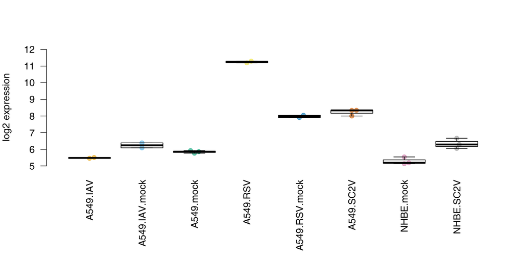

```r
par(mar=c(8, 4, 4, 2))
showgene(lcounts[ "ENSG00000185507",  ],
  covar$group)
```

## Gene expression

```r
library(gplots)
library(RColorBrewer)
pal <- colorRampPalette(colors=c("purple", "black", "cyan"))(13)
heatmap.2(lcounts[sel.genes, ], trace="n", scale="r",
  labRow=annot$SYMBOL[sel.genes], dendrogram="r",
  labCol=covar$group, margin=c(8,5), col=pal)
```

## Gene expression

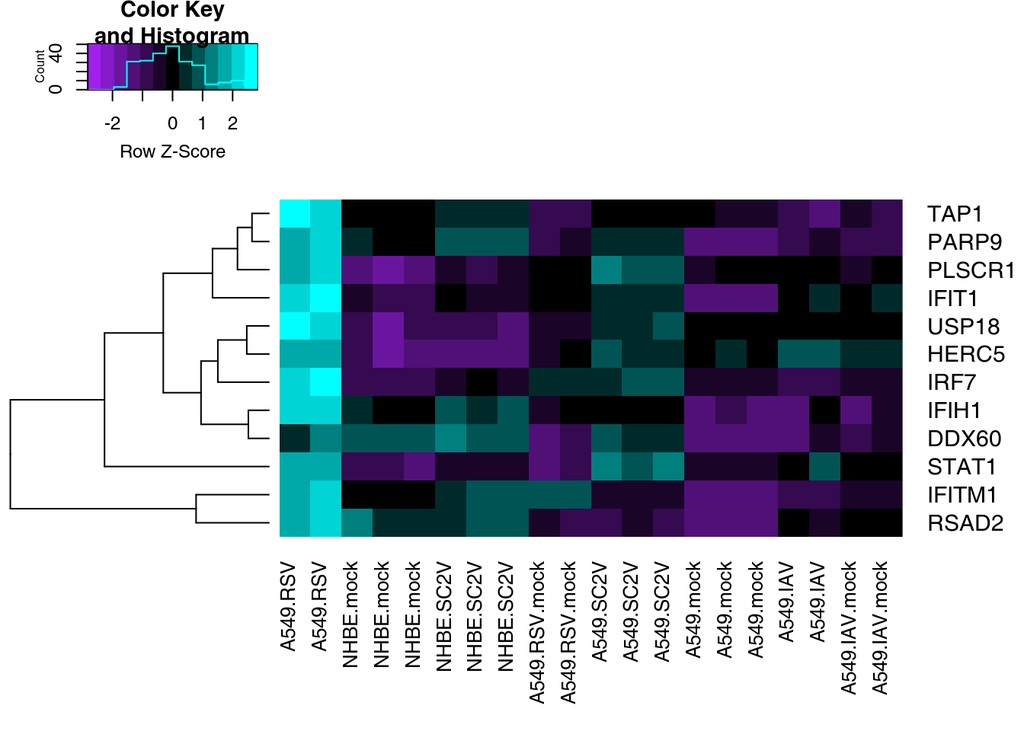

## Module eigengenes

- Select genes from a gene set
- Run a PCA only on this set

```r
## for PCA, we need to remove genes with no variance
sel <- apply(lcounts, 1, var) > 0
pca_full <- prcomp(t(lcounts[sel, ]), scale.=TRUE)

## get the genes belonging to the interferon gene set
pca_mod <- prcomp(t(lcounts[ sel.genes, ]), scale.=TRUE)
```

## Module eigengenes

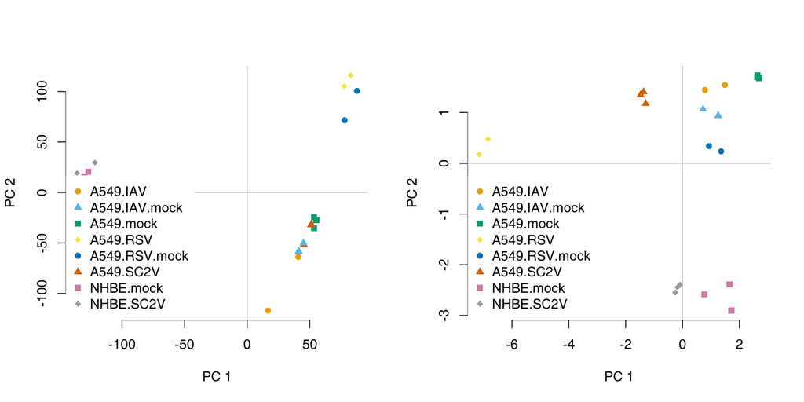

## Using eigengenes

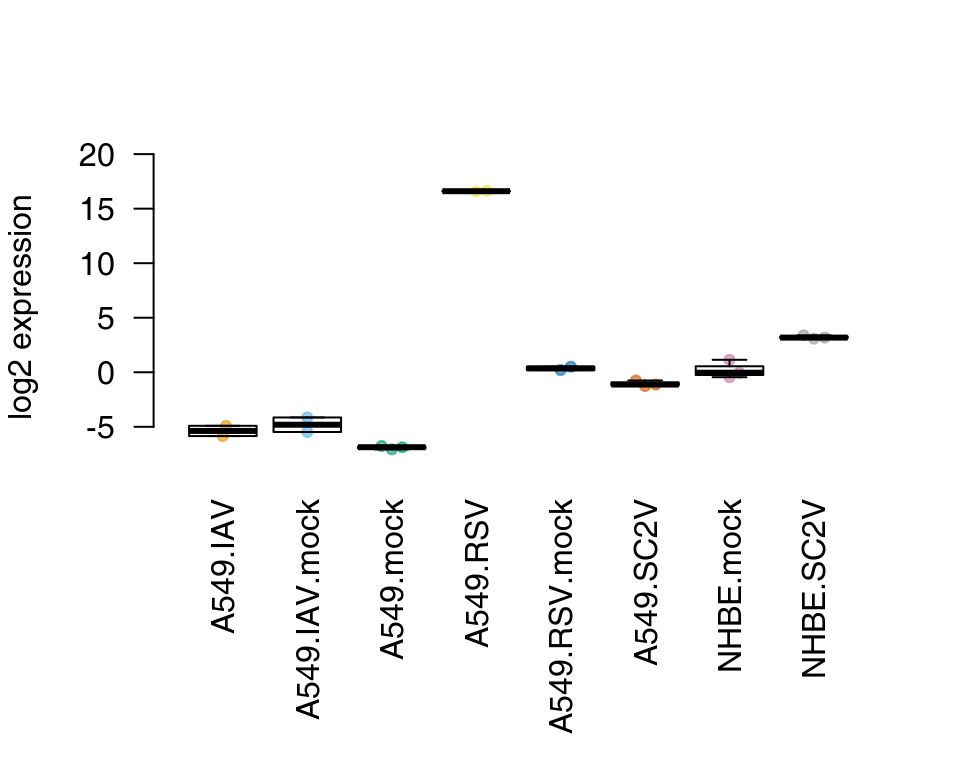

```r
par(mar=c(8, 4, 4, 2))
all_eig <- eigengene(lcounts,
  annot$SYMBOL, mset=htmod)
showgene(all_eig[ "INTERFERON_ALPHA_RESPONSE", ],
  covar$group, cex=.7)
```

- Eigengene is a kind of an "average" expression of a gene set
- You can use eigengenes to illustrate what is happening in a gene set as a whole
- Eigengenes are the first components of a PCA of gene expression in a gene set
- tmod eigengene function takes an expression matrix, the corresponding gene IDs and (optionally) the tmod database with the modules
- the eigengene function returns a matrix with a row for each gene set in the tmod database

## Let us run an enrichment test

We are using tmod CERNO statistic, default tmod gene sets.

```r
res <- results(ds, contrast=c("group", "A549.RSV", "A549.mock"))
res <- merge(annot, data.frame(res), by.x="PrimaryID", by.y=0)
l <- res$SYMBOL[ order(res$padj) ]
res_tmod <- tmodCERNOtest(l)

head(res_tmod, 5)
```

```
##              ID                        Title     cerno  N1       AUC      cES      P.Value    adj.P.Val
## LI.M4.0 LI.M4.0 cell cycle and transcription 1402.5317 323 0.7486995 2.171102 5.551625e-58 1.920862e-55
## LI.M4.1 LI.M4.1               cell cycle (I)  830.3610 140 0.8990443 2.965575 6.570834e-56 1.136754e-53
## LI.M4.2 LI.M4.2        PLK1 signaling events  200.9440  32 0.9089438 3.139750 4.693556e-16 5.413235e-14
## LI.M127 LI.M127   type I interferon response  119.5381  12 0.9863650 4.980755 1.172557e-14 1.014262e-12
## LI.M103 LI.M103             cell cycle (III)  249.8648  51 0.8232203 2.449655 2.048966e-14 1.417885e-12
```

## Are the gene sets overlapping?

```r
m1 <- "LI.M4.1"  # cell cycle (I)
m2 <- "LI.M4.2"  # PLK1 signaling events
m3 <- "LI.M22.0" # mismatch repair
glist <- getModuleMembers(c(m1, m2, m3))
intersect(glist[[1]], glist[[2]])
```

## Are the gene sets overlapping?

```r
library(VennDiagram)
## grid graphics is between basic R and ggplot.
## No need to understand it.
grid.newpage()
venn.plot <- venn.diagram(glist, NULL,
  fill=brewer.pal(3, "Pastel1"),
  cex=1.5, cat.cex=1.5,
  lty="blank",
  fontfamily="sans", cat.fontfamily="sans")
grid.draw(venn.plot)
```

## Are the gene sets overlapping?

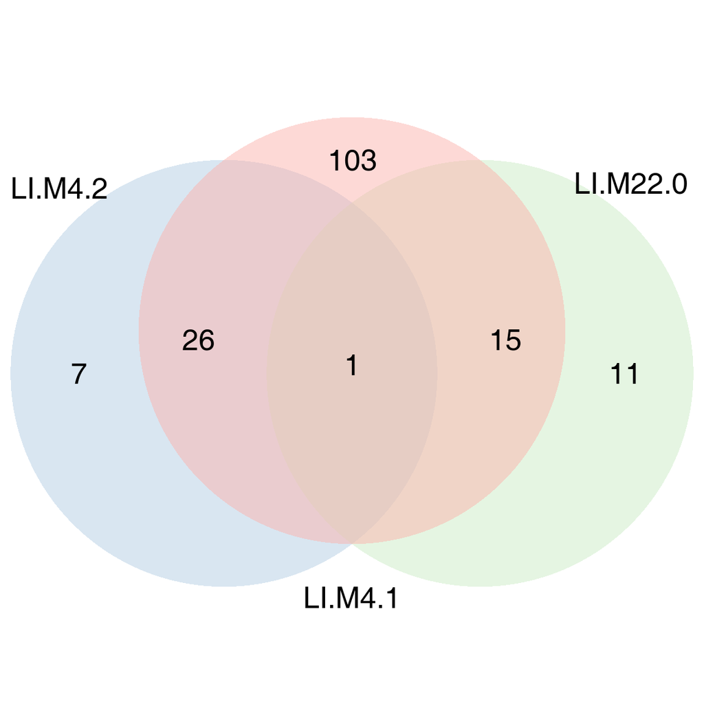

## Are the gene sets overlapping?

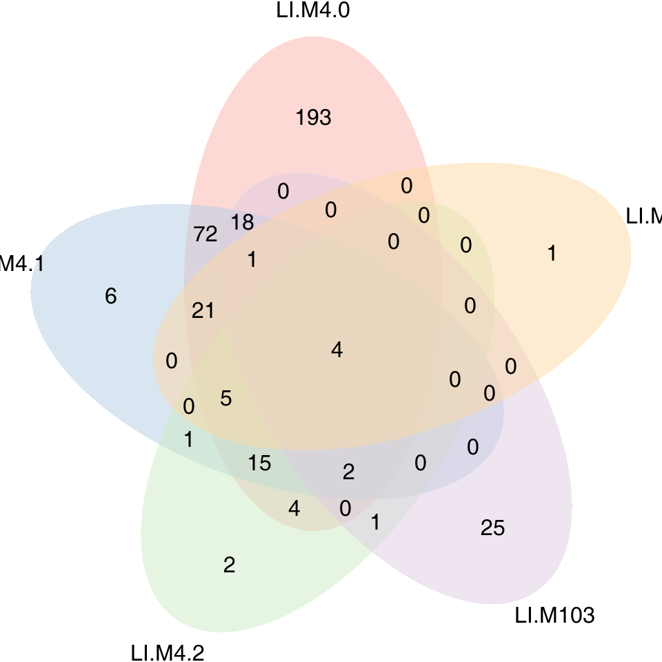

## Upset plots

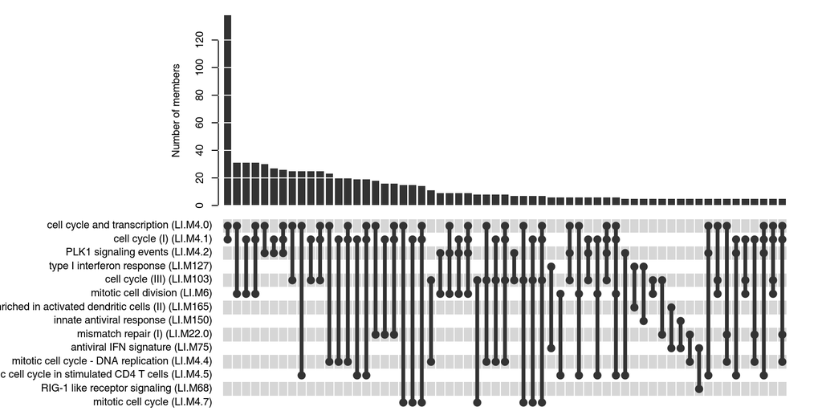

```r
par(mar=c(0, 0, 0, 0), cex=.7)
upset(res_tmod$ID[1:15], min.overlap=5, group=FALSE)
```

## Jaccard index

Show the similarity of two sets

\[J(A,B) = \frac{|A \cap B|}{|A \cup B|}\]

That is, the number of common elements divided by the total number of elements.

## Jaccard index: visualization

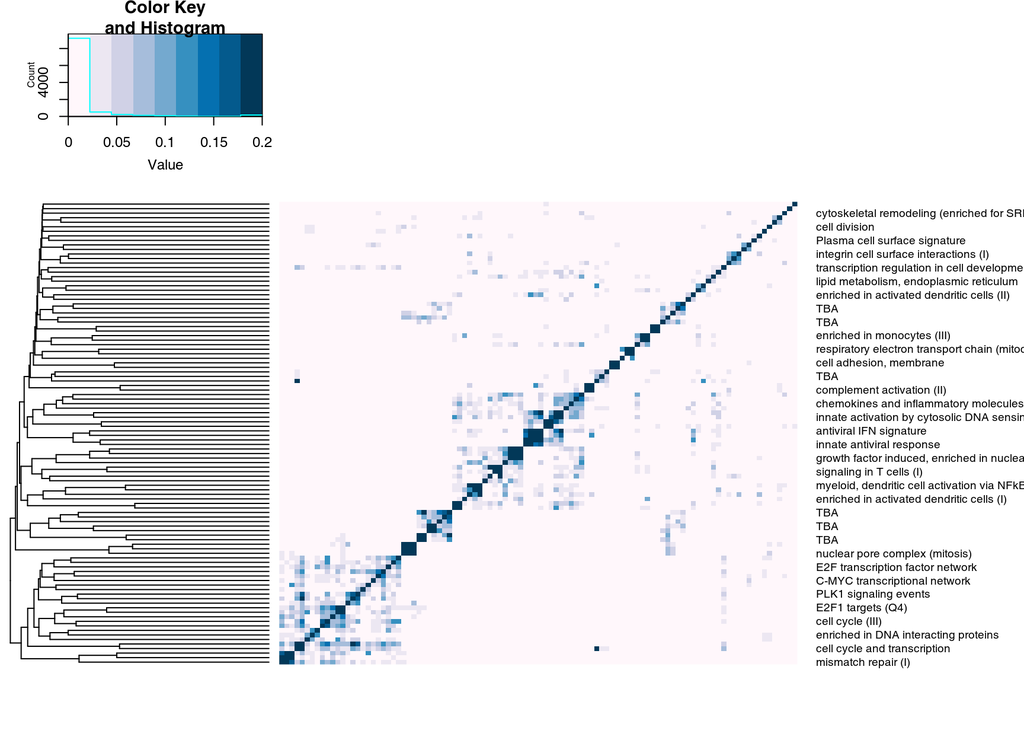

```r
simmat <- modOverlaps(res_tmod$ID, stat="jaccard")
heatmap.2(simmat,
  trace="n", scale="n", dendrogram="r", symm=TRUE,
  col=brewer.pal(9, "PuBu"),
  labRow=res_tmod$Title, margin=c(4,12),
  labCol="",
  breaks=seq(0, .2, length.out=10))
```

## Group gene sets

```r
groups <- modGroups(res_tmod$ID, min.overlap=5)
sapply(groups, length)
```

```
##   LI.M4.0    LI.M20 LI.M112.1 LI.M111.1  LI.M86.0    LI.M13  LI.M43.1   LI.M160  LI.M89.0   LI.M172    LI.M56    LI.M31   LI.M205   LI.M148   LI.M181    LI.M29 LI.M184.0
##        40         3         2         2         1         1         3         1         3         1         1         1         1         1         1         1         1
##  LI.M27.0   LI.M147   LI.M153 LI.M106.0   LI.M1.0  LI.M70.0  LI.M72.0     LI.S3   LI.M116   LI.M139   LI.M216    LI.M92   LI.M146    LI.M34 LI.M133.0  LI.M32.2   LI.M108
##         2         1         2         3         1         1         5         1         1         1         2         1         1         1         2         1         1
##    LI.M59    LI.M53   LI.M209   LI.M231   LI.M110    LI.M85    LI.S11  LI.M88.1   LI.M185   LI.M180   LI.M119
##         1         1         1         1         1         1         1         1         1         1         1
```

```r
groups <- groups[sapply(groups, length) > 1]
```

## Group gene sets

```r
res_tmod[ res_tmod$ID %in% groups[[2]], ]
```

```
##                ID                             Title     cerno N1       AUC      cES      P.Value    adj.P.Val
## LI.M20     LI.M20 AP-1 transcription factor network 104.04366 14 0.8851805 3.715845 1.108537e-10 2.950414e-09
## LI.M35.0 LI.M35.0          signaling in T cells (I)  74.06152 14 0.6212677 2.645054 4.942110e-06 4.749917e-05
## LI.M0       LI.M0                targets of FOSL1/2  44.04549 11 0.6961374 2.002068 3.500452e-03 1.563956e-02
```

```r
res_tmod[ res_tmod$ID %in% groups[[3]], ]
```

```
##                  ID                      Title    cerno N1       AUC     cES      P.Value    adj.P.Val
## LI.M112.1 LI.M112.1 complement activation (II) 76.49020 10 0.8331496 3.82451 1.535015e-08 2.795343e-07
## LI.M112.0 LI.M112.0  complement activation (I) 93.57345 17 0.6883997 2.75216 1.808108e-07 2.606690e-06
```

## Upset plot with grouping

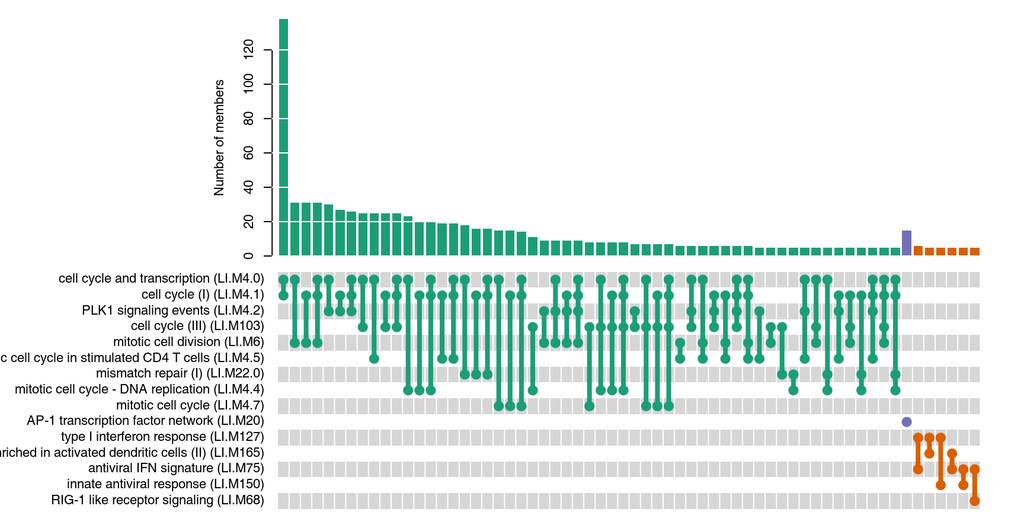

```r
par(mar=c(0, 0, 0, 0), cex=.7)
upset(res_tmod$ID[1:15], min.overlap=5, group=TRUE)
```

## Leading edge analysis

## Note the hump

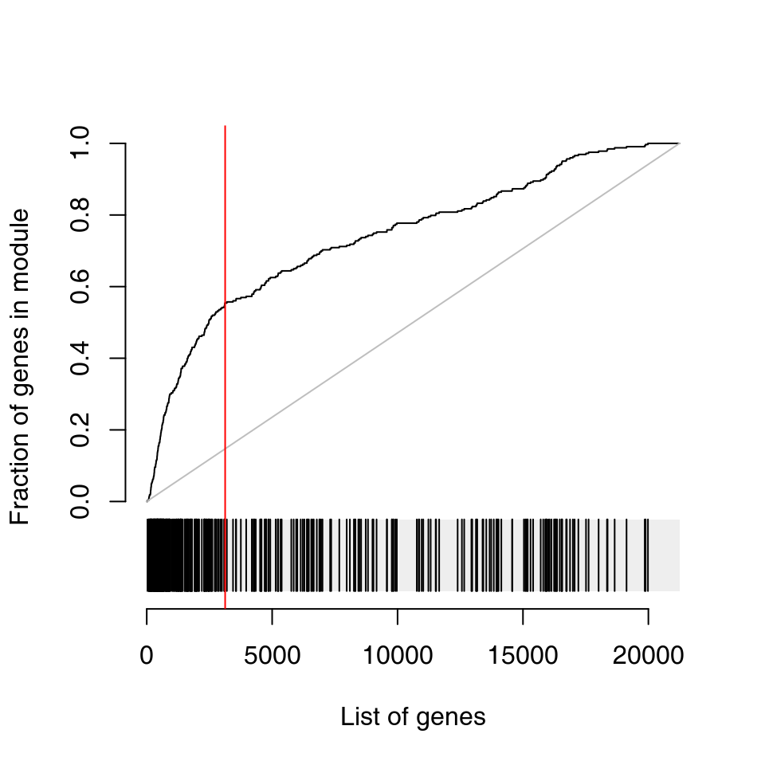

```r
evidencePlot(l, "LI.M4.0")
abline(v=3126, col="red")
```

- Until a certain point, the ROC curve diverges from the diagonal
- Then it starts to converge again
- Genes to the left of this point ("leading edge") are driving the enrichment

## Note the hump

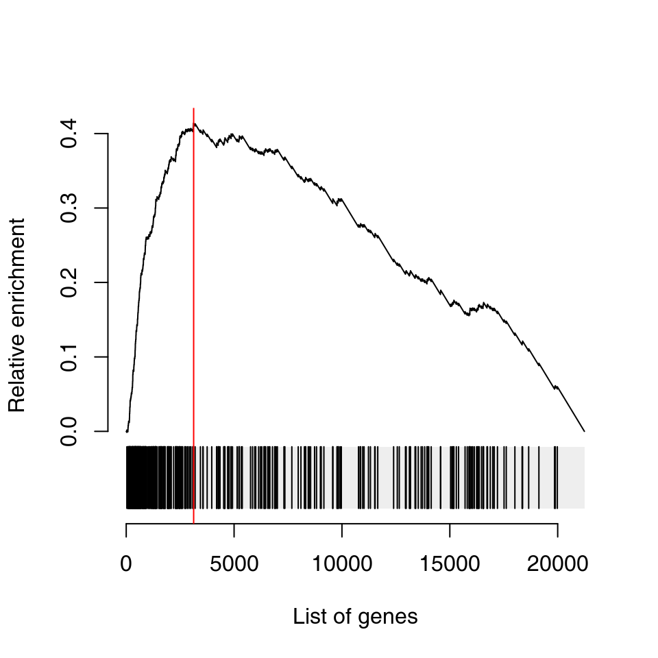

```r
evidencePlot(l, "LI.M4.0", style="gsea")
abline(v=3126, col="red")
```

- Until a certain point, the ROC curve diverges from the diagonal
- Then it starts to converge again
- Genes to the left of this point ("leading edge") are driving the enrichment

## GSEA-style ROC curve

The values on that second curve are the difference between the proportion of genes in the gene set to the left of a given point and the proportion of genes *not* in the gene set to the left of this point.

\[f(i) = \frac{b_i}{B} - \frac{i - b_i}{N - B}\]

Where

- \(i\) – position in the gene list
- \(b_i\) – number of genes in the gene set on positions \(1\cdots i\)
- \(B\) – total number of genes in the gene set
- \(N\) – total number of genes

## Getting the Leading Edge genes

```r
lea <- tmodLEA(l, res_tmod$ID[1:25])
head(tmodLEASummary(lea))
```

```
##        ID                        Title   N  LEA  fraction
## 1 LI.M4.0 cell cycle and transcription 323 3116 0.5541796
## 2 LI.M4.1               cell cycle (I) 140 3116 0.8142857
## 3 LI.M4.2        PLK1 signaling events  32 2489 0.8437500
## 4 LI.M127   type I interferon response  12 1176 1.0000000
## 5 LI.M103             cell cycle (III)  51 4879 0.7450980
## 6   LI.M6        mitotic cell division  28 2317 0.8214286
```

```r
lea[["LI.M75"]]
```

```
##  [1] "IRF7"     "OAS1"     "IFIT1"    "DDX58"    "PML"      "IFIH1"    "HERC5"    "OAS3"     "DDX60"    "BCL3"     "RSAD2"    "DHX58"    "SERPING1" "IL1B"     "ELANE"
## [16] "CXCL10"   "RARA"
## attr(,"N")
## [1] 22
## attr(,"LEA")
## [1] 5147
## attr(,"LEA.frac")
## [1] 0.7727273
```

## Visualization

Since `lea` object is just a list of gene sets, we can use all the mentioned methods to visualize it.

## Jaccard index

Note: `modOverlaps` accepts a list of gene sets as an input.

```r
simmat <- modOverlaps(lea, stat="jaccard")
heatmap.2(simmat,
  trace="n", scale="n", dendrogram="r", symm=TRUE,
  col=brewer.pal(9, "PuBu"),
  labRow=res_tmod$Title, margin=c(4,12),
  labCol="",
  breaks=seq(0, .2, length.out=10))
```

## Jaccard index

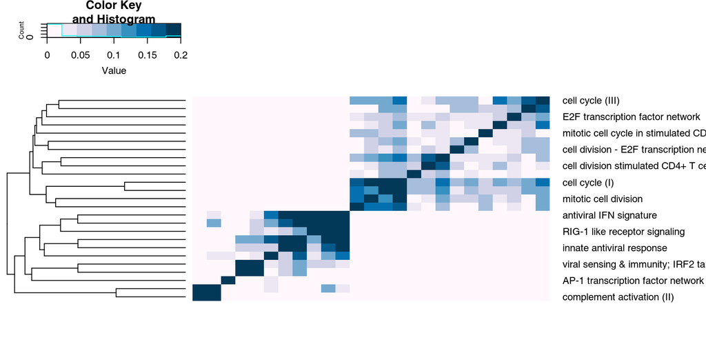

## Upset plot

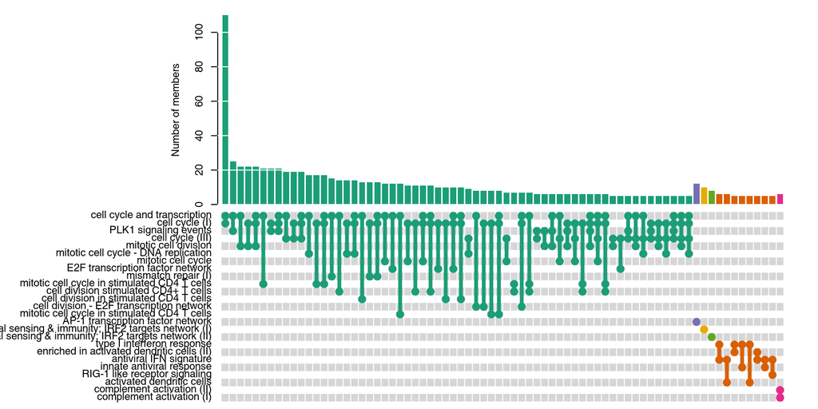

```r
par(mar=c(0, 0, 0, 0), cex=.7)
upset(lea, min.overlap=5, group=TRUE, labels=res_tmod$Title[1:25])
```